# acea_water_petrigano

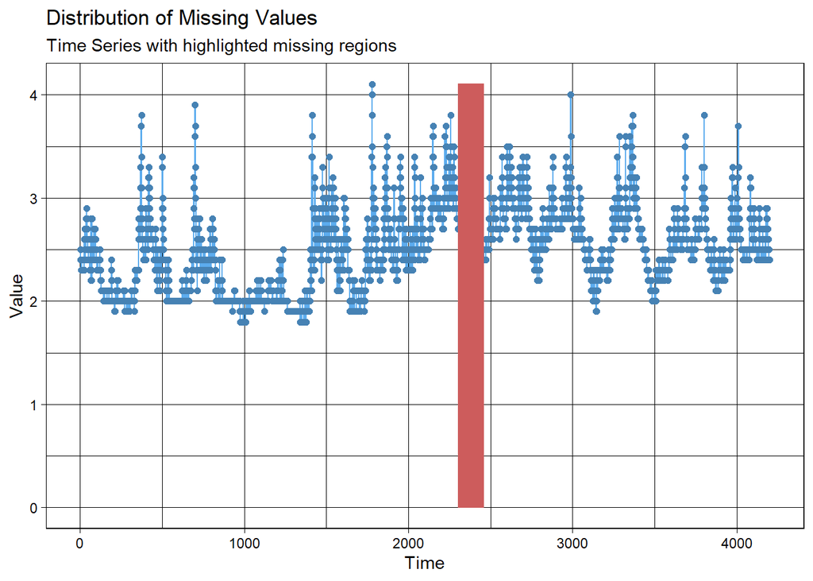

```r
df$` Hydrometry` <- ifelse(df$` Hydrometry` == 0, NaN, df$` Hydrometry`)
times_hh <- ts(df$` Hydrometry`, start = df$Date[1], frequency=1)
ggplot_na_distribution(times_hh)
```

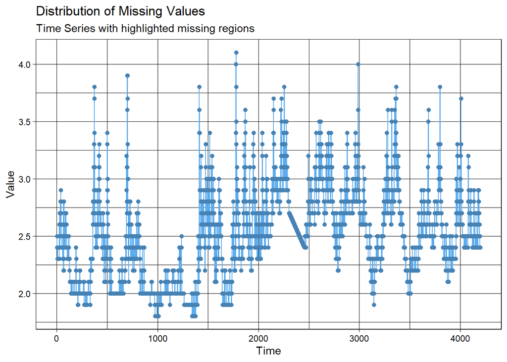

```r
times_hh <- na_interpolation(times_hh, option="linear")
ggplot_na_distribution(times_hh)
```

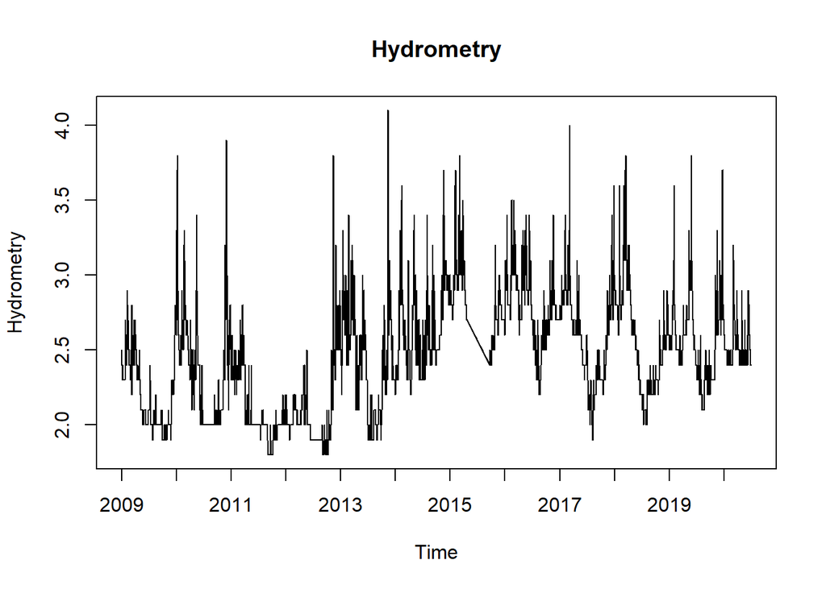

```r
plot( times_hh,xlab = "Time", ylab = "Hydrometry", main="Hydrometry", axes=FALSE, type="l")
axis(1,at=seq(df$Date[1], df$Date[length(df$Date)], by="years"),labels=unique(as.character(df$Date, format= "%Y")))
axis(2)
box()
```

### try to unsderstand in what way it will be more efficient to predict

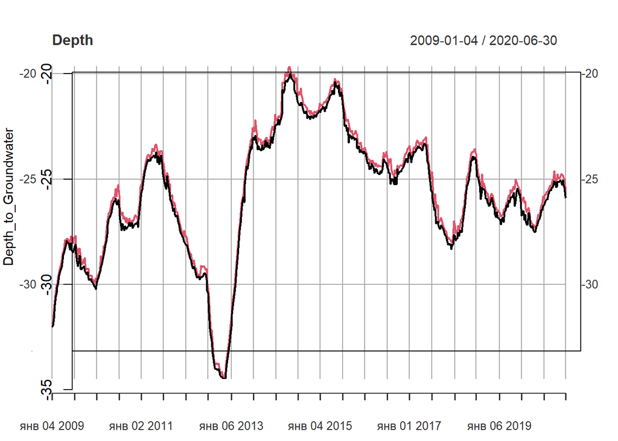

```r
times_dd <- ts(df$Depth_to_Groundwater, start = df$Date[1], frequency=1)
times_dd <- na_interpolation(times_dd, option="spline")
time_dd_week <- period.apply(as.xts(times_dd), endpoints(as.xts(times_dd), "weeks"), range)
times_dd <- na_interpolation(time_dd_week, option="spline")
plot( time_dd_week,xlab = "Time", ylab = "Depth_to_Groundwater", main="Depth", axes=FALSE, type="l")
axis(1,at=seq(df$Date[1], df$Date[length(df$Date)], by="years"),labels=unique(as.character(df$Date, format= "%Y")))
axis(2)
box()
```

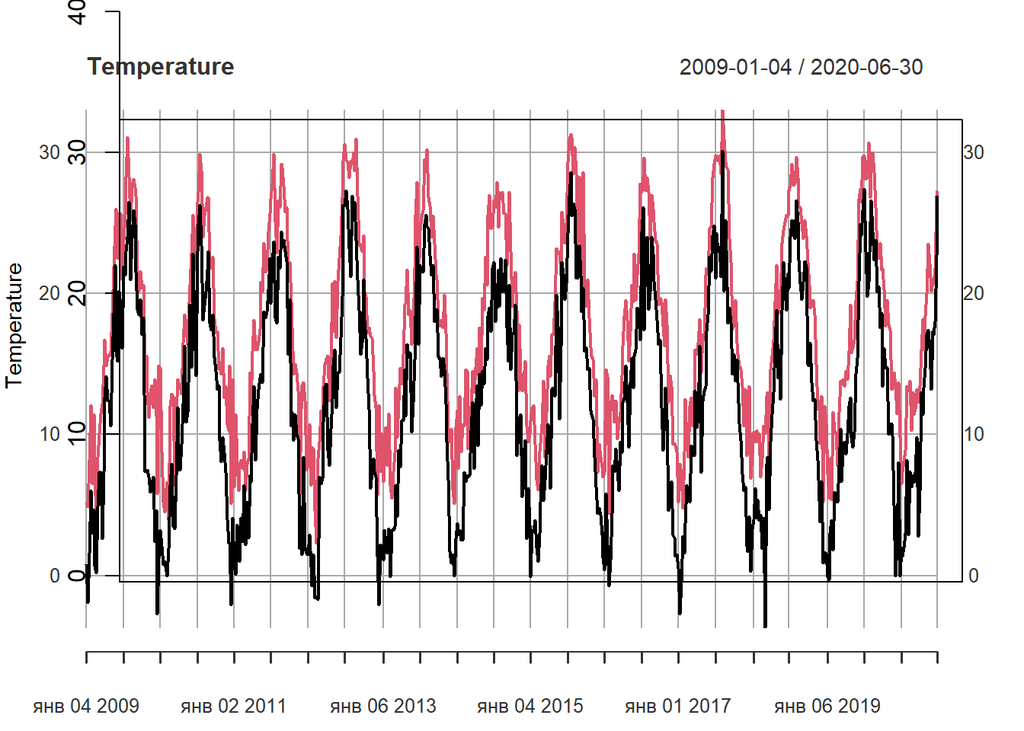

```r
times_t <- ts(df$Temperature, start = df$Date[1], frequency=1)
times_tt_week <- period.apply(as.xts(times_t), endpoints(as.xts(times_t), "weeks"), range)
plot( times_tt_week,xlab = "Time", ylab = "Temperature", main="Temperature", axes=FALSE, type="l")
axis(1,at=seq(df$Date[1], df$Date[length(df$Date)], by="years"),labels=unique(as.character(df$Date, format= "%Y")))
axis(2)
box()
```

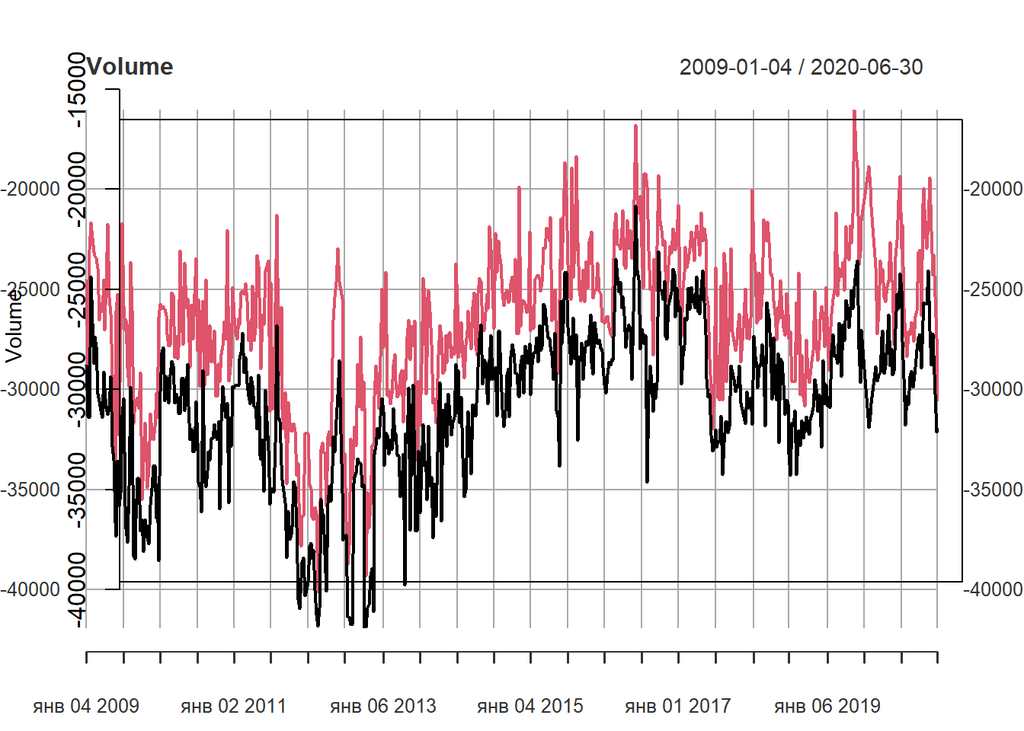

```r
times_vv <- ts(df$` Volume`, start = df$Date[1], frequency=1)
times_vv_week <- period.apply(as.xts(times_vv), endpoints(as.xts(times_vv), "weeks"), range)
times_vv_week <- na_interpolation(times_vv_week, option="linear")
plot( times_vv_week,xlab = "Time", ylab = "Volume", main="Volume", axes=FALSE, type="l")
axis(1,at=seq(df$Date[1], df$Date[length(df$Date)], by="years"),labels=unique(as.character(df$Date, format= "%Y")))
axis(2)
box()
```

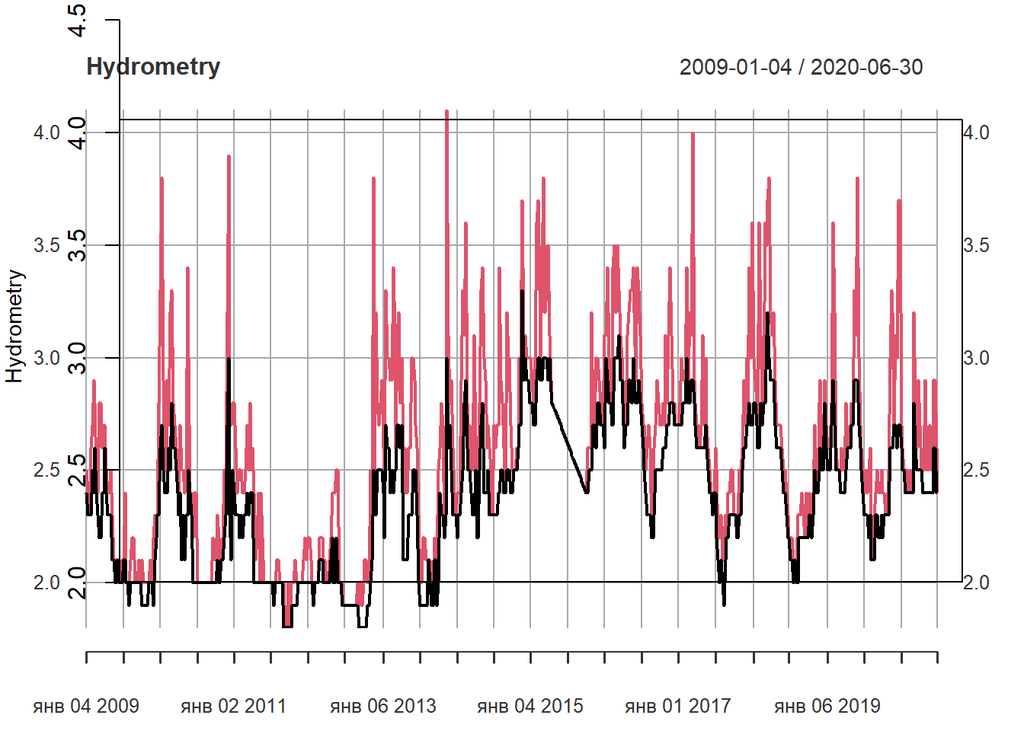

```r
times_hh <- ts(df$` Hydrometry`, start = df$Date[1], frequency=1)
times_hh_week <- period.apply(as.xts(times_hh), endpoints(as.xts(times_hh), "weeks"), range)
times_hh_week <- na_interpolation(times_hh_week, option="linear")
plot( times_hh_week,xlab = "Time", ylab = "Hydrometry", main="Hydrometry", axes=FALSE, type="l")
axis(1,at=seq(df$Date[1], df$Date[length(df$Date)], by="years"),labels=unique(as.character(df$Date, format= "%Y")))
axis(2)
box()
```

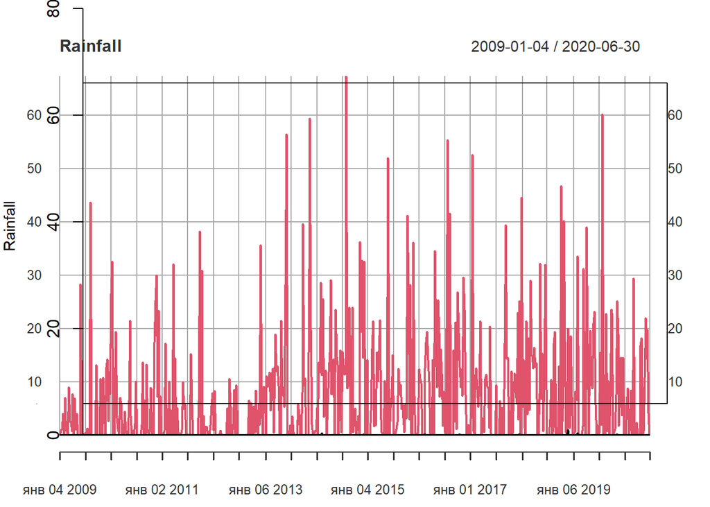

```r
times <- ts(df$Rainfall, start = df$Date[1], frequency=1)
times_week <- period.apply(as.xts(times), endpoints(as.xts(times), "weeks"), range)
plot( times_week,xlab = "Time", ylab = "Rainfall", main="Rainfall", axes=FALSE)
axis(1,at=seq(df$Date[1], df$Date[length(df$Date)], by="years"),labels=unique(as.character(df$Date, format= "%Y")))
axis(2)
box()
```

We can say that it is not obvious to resample data, we can make predictions for one day and it will be quite accurate and full. If we will take for day or month we can lose some info that will be critical for people’ life. Also there is no such big outliers that require smoothing

### Stationarity

We should understand the character of the data to analyze correctly and may be we can use easier methods. So we need to check. We must determine if the data was generated by a stationary process, and possibly to transform it so it has the properties of a sample generated by such a process. In ARIMA data must be stationar.

For test we will use Augmented Dickey-Fuller Test

```r
adf.test(df$Rainfall,alternative="stationary")
```

```
##
##  Augmented Dickey-Fuller Test
##
## data:  df$Rainfall
## Dickey-Fuller = -14.579, Lag order = 16, p-value = 0.01
## alternative hypothesis: stationary
```

```r
clean_df <- na.omit(df)
adf.test(clean_df$Depth_to_Groundwater, alternative = "stationary")
```

```
##
##  Augmented Dickey-Fuller Test
##
## data:  clean_df$Depth_to_Groundwater
## Dickey-Fuller = -1.8431, Lag order = 15, p-value = 0.6448
## alternative hypothesis: stationary
```

```r
adf.test(clean_df$Temperature, alternative = "stationary")
```

```
##
##  Augmented Dickey-Fuller Test
##
## data:  clean_df$Temperature
## Dickey-Fuller = -3.5295, Lag order = 15, p-value = 0.03943
## alternative hypothesis: stationary
```

```r
adf.test(clean_df$` Volume`, alternative = "stationary")
```

```
##
##  Augmented Dickey-Fuller Test
##
## data:  clean_df$` Volume`
## Dickey-Fuller = -5.7894, Lag order = 15, p-value = 0.01
## alternative hypothesis: stationary
```

```r
adf.test(clean_df$` Hydrometry`, alternative = "stationary")
```

```
##
##  Augmented Dickey-Fuller Test
##
## data:  clean_df$` Hydrometry`
## Dickey-Fuller = -5.5771, Lag order = 15, p-value = 0.01
## alternative hypothesis: stationary
```

If p - value is less then 0.05 it means that stationary data else non - stationary and we need to do some actions with data. In our case only depth has non - stationary distribution.

```r
depth <- na_interpolation(df$Depth_to_Groundwater, option = "linear")
depth <- log10(abs(depth))
adf.test(depth, alternative = "stationary")
```

```
##
##  Augmented Dickey-Fuller Test
##
## data:  depth
## Dickey-Fuller = -1.704, Lag order = 16, p-value = 0.7037
## alternative hypothesis: stationary
```

```r
#depth <- df$Depth_to_Groundwater
depth <- diff(depth) # make it stationary
#depth <- df$Depth_to_Groundwater - shift(df$Depth_to_Groundwater, n=1, type = 'shift')
depth <- na_interpolation(depth, option = "linear")
adf.test(depth, alternative = "stationary")
```

```
##
##  Augmented Dickey-Fuller Test
##
## data:  depth
## Dickey-Fuller = -12.882, Lag order = 16, p-value = 0.01
## alternative hypothesis: stationary
```

As we can see p-value is less than 0.05 that means that we got stationary data Get trend, seasonal and noise. Compare with reality

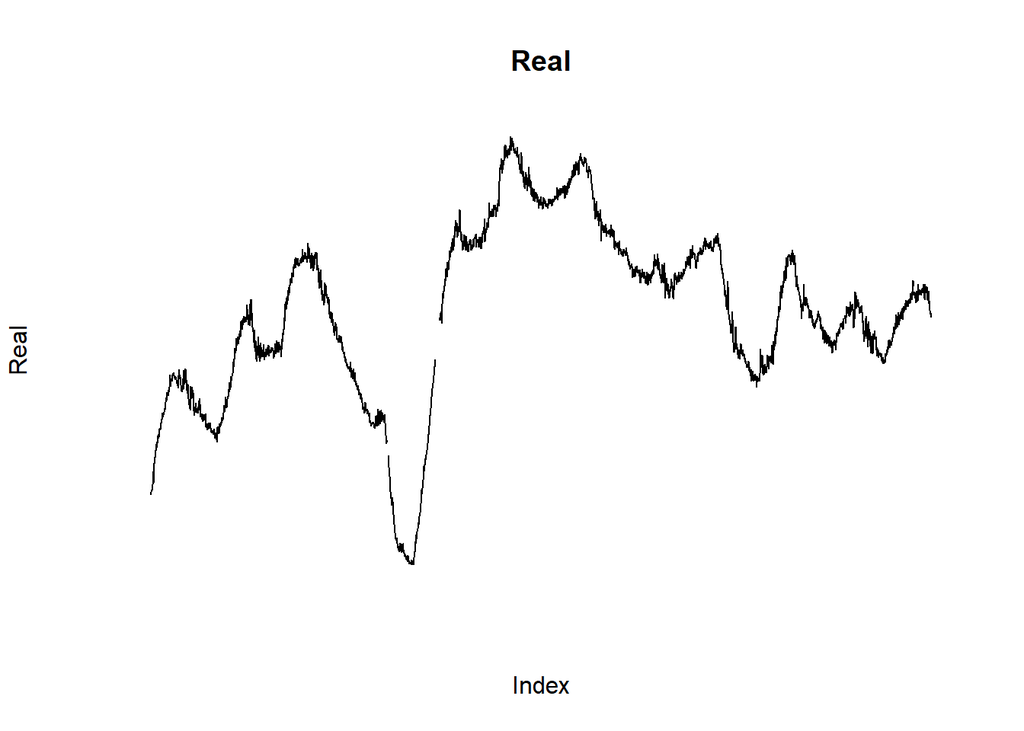

```r
depth_ts <- ts(depth, start = df$Date[1], frequency=365)
depth_ts <- diff(depth_ts)
decomposed_ts <- decompose(depth_ts, type=c("additive"))
plot( df$Depth_to_Groundwater, ylab = "Real", main="Real", axes=FALSE, type="l")+geom_line()
```

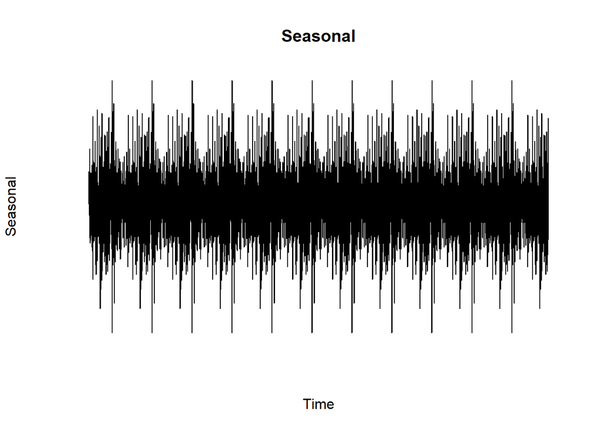

```r
plot( decomposed_ts$seasonal, ylab = "Seasonal", main="Seasonal", axes=FALSE, type="l")
```

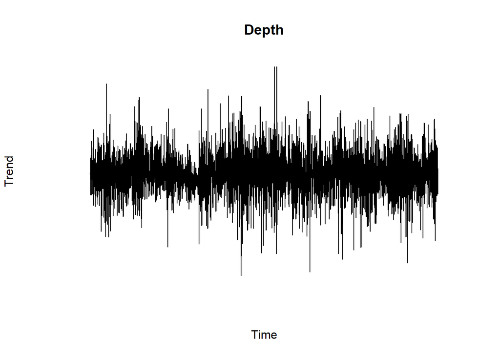

```r
plot( decomposed_ts$trend, ylab = "Trend", main="Depth", axes=FALSE, type="l")
```

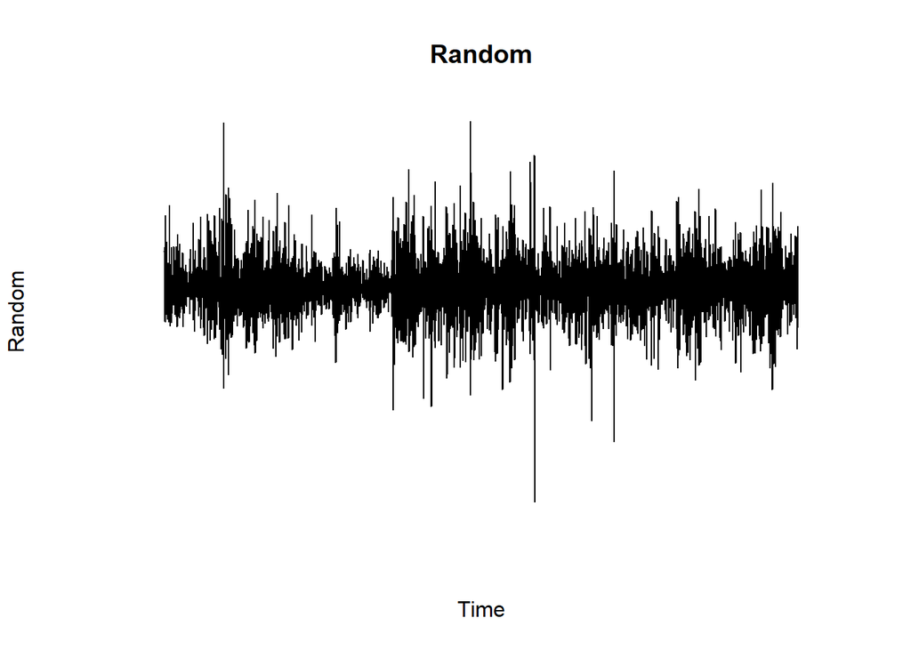

```r
plot( decomposed_ts$random, ylab = "Random", main="Random", axes=FALSE, type="l")
```

As we can see wa have stationary data

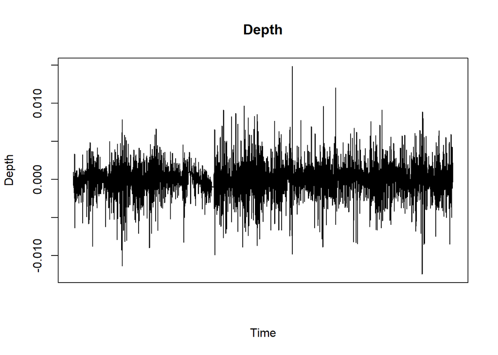

```r
plot(depth,type="l", xlab = "Time", ylab = "Depth", main="Depth", axes=FALSE)
axis(1,at=seq(df$Date[1], df$Date[length(df$Date)], by="years"),labels=unique(as.character(df$Date, format= "%Y")))
axis(2)
box()
```

## Analyse data

the most convinient and normal is to analyse seasonal

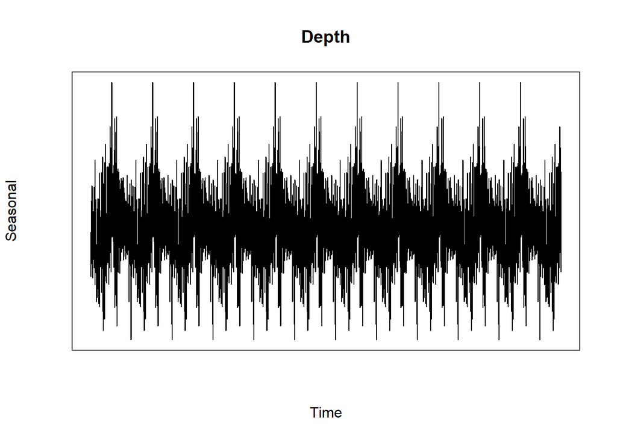

```r
depth_ts <- ts(depth, start = df$Date[1], frequency=365)
depth_ts <- na_interpolation(depth_ts, option = "linear")
decomposed_ts <- decompose(depth_ts, type=c("additive"))
plot( decomposed_ts$seasonal, xlab="Time", ylab = "Seasonal", main="Depth", axes=FALSE, type="l")
box()
```

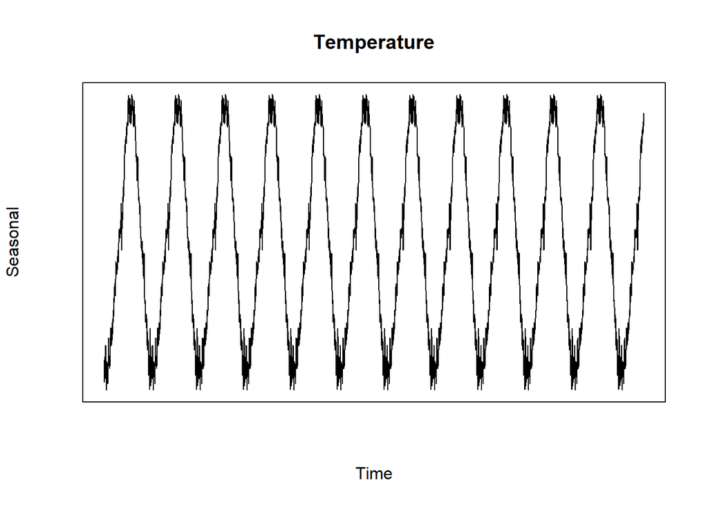

```r
df$Temperature <- na_interpolation(df$Temperature, option = "linear")
temperature_ts <- ts(df$Temperature, start = df$Date[1], frequency=365)
decomposed_ts <- decompose(temperature_ts, type=c("additive"))
plot( decomposed_ts$seasonal, xlab="Time", ylab = "Seasonal", main="Temperature", axes=FALSE, type="l")
box()
```

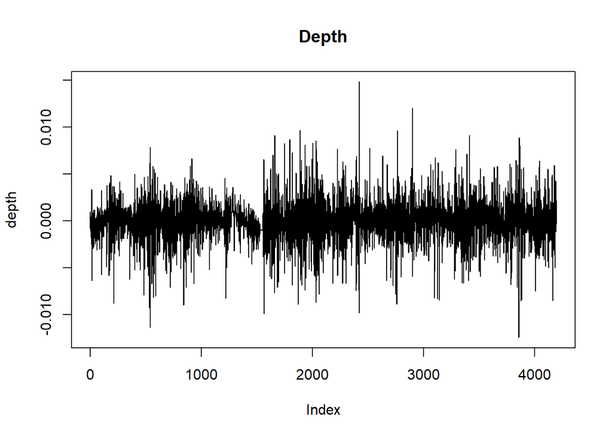

```r
plot(depth, type='l', main="Depth")
```

We see that there is no increasing or decreasing for a long time intervals, that means that we got stationary data.

## Arima model

We have stationary data so we can use ARIMA model.

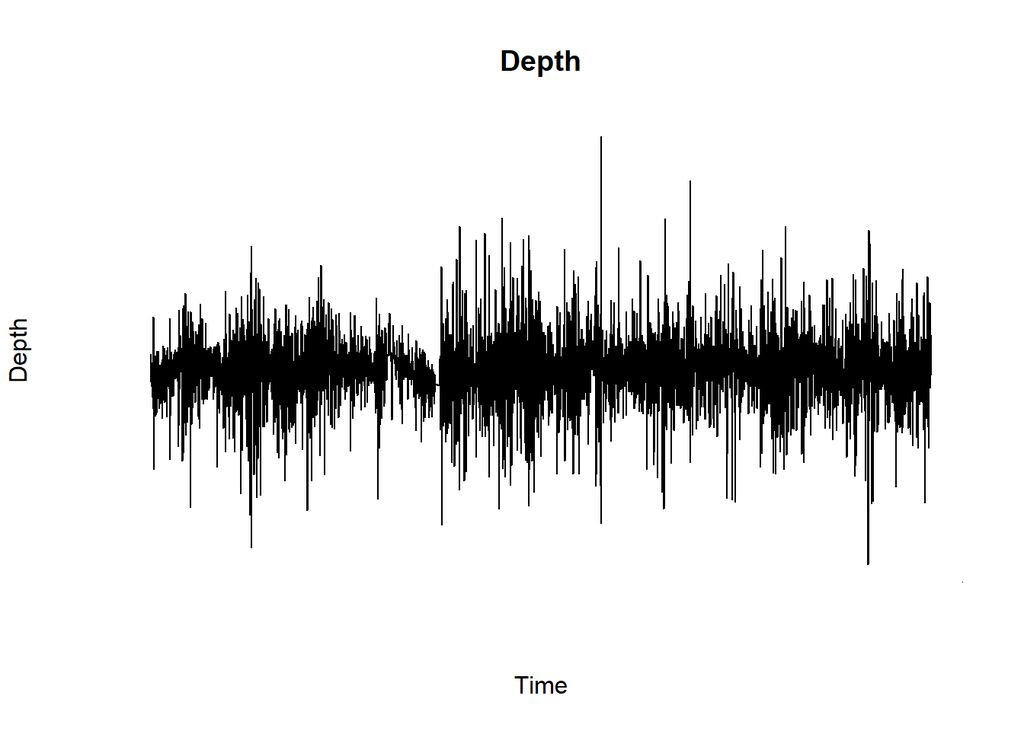

```r
plot( depth,xlab = "Time", ylab = "Depth", main="Depth", axes=FALSE, type="l")
axis(1,at=seq(df$Date[1], df$Date[length(df$Date)], by="years"),labels=unique(as.character(df$Date, format= "%Y")))
```

We will build ACF, PACF functions.

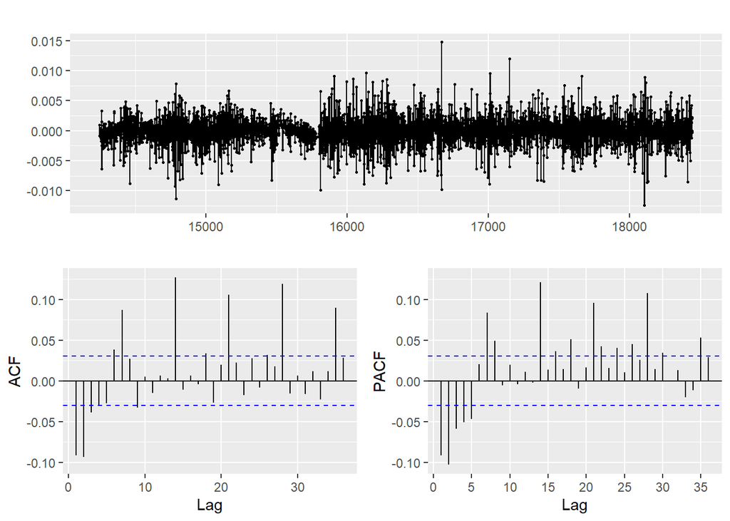

```r
depth_ts <- ts(depth, start = df$Date[1], frequency=1)
depth_ts %>% ggtsdisplay(main="")
```

build in more convinient way graphics for acf and pacf;

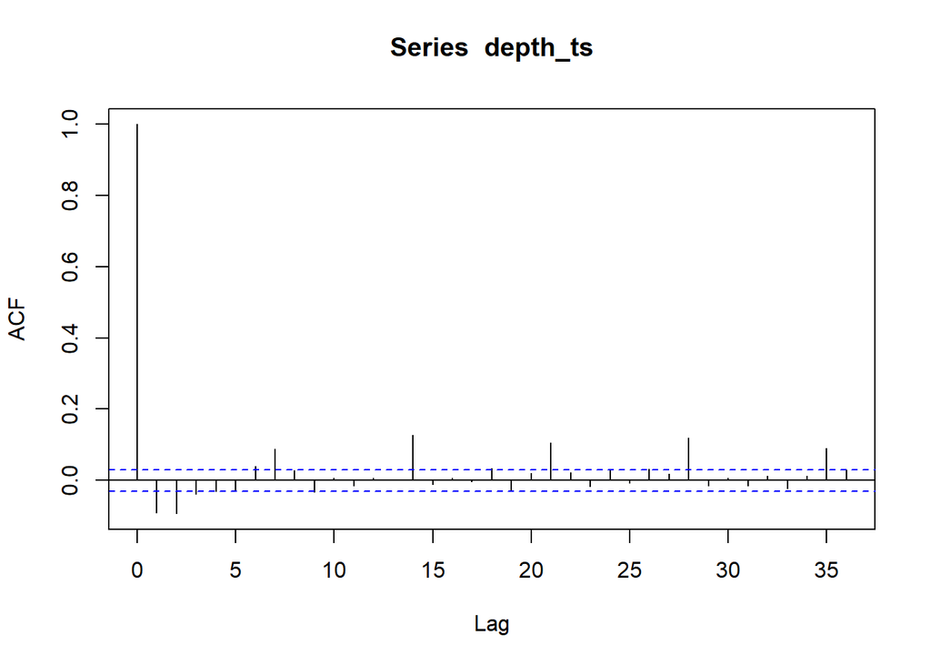

```r
acf(depth_ts)
```

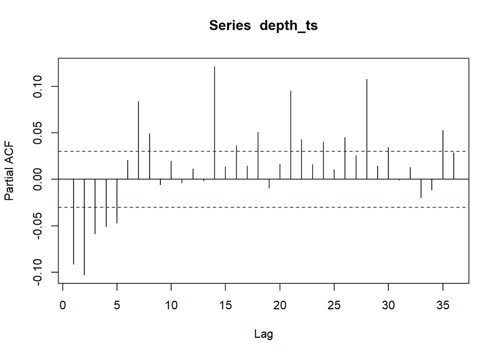

```r
pacf(depth_ts)
```

From the graphics we can suppose that from ACF and adf test q = 16, from PACF - p=13-15. We will variants and find a model with the lowest AICc. Also we will look at residual plots and notice if lag is between threshold values of autocorrelation functions.

```r
arima_1 <- Arima(depth_ts, order=c(13,1,16))
arima_1
```

```
## Series: depth_ts
## ARIMA(13,1,16)
##
## Coefficients:
```

```
##          ar1      ar2      ar3      ar4      ar5     ar6     ar7     ar8
##       -0.619  -0.3518  -0.2335  -0.1159  -0.2377  0.2273  0.7465  0.3655
## s.e.     NaN      NaN      NaN      NaN      NaN  0.2813     NaN  0.2316
##          ar9     ar10     ar11     ar12     ar13      ma1      ma2      ma3
##       0.0999  -0.0152  -0.1312  -0.0104  -0.4776  -0.4998  -0.3361  -0.0819
## s.e.     NaN      NaN   0.2205   0.0890   0.2558      NaN      NaN   0.1366
##           ma4     ma5      ma6      ma7     ma8     ma9    ma10    ma11
##       -0.0961  0.1589  -0.4107  -0.4632  0.4950  0.2646  0.0756  0.0929
## s.e.   0.1979  0.2978   0.1939   0.3226  0.0277     NaN  0.1333  0.2064
##          ma12    ma13     ma14    ma15    ma16
##       -0.1456  0.4217  -0.5109  0.0095  0.0656
## s.e.   0.2947  0.1872   0.3354  0.0398  0.0235
##
## sigma^2 estimated as 4.409e-06:  log likelihood=19931.37
## AIC=-39802.75   AICc=-39802.3   BIC=-39612.48
```